# The Demographics of the Opioid Crisis

### May 15, 2021

## Introduction

Opioids are both a miracle of modern medicine and a scourge. Without painkillers, many modern medical and dental procedures and their aftermath would be intolerable. Opioids have proven to be strong and effective painkillers. On the other hand, over 50,000 lives were lost due to opioid abuse during 2019 alone (https://www.cdc.gov/drugoverdose/data/statedeaths.html). Drug addiction has been a major health issue in the United State for many years. Opioids, in particular synthetic opioids, currently dominate drug overdose deaths. The problem of opioid addiction will persist long after Covid-19. Unlike Covid-19, there is no vaccine to make it go away.

This project is motivated by compassionate concerns and practical implications. As mentioned in the opening paragraph, many people are hurt by opioids. Any insight gained about demographic factors contributing to opioid addiction could alleviate some of this pain experienced by many Americans. A practical implication of this study is to determine whether we are fighting the right battle against opioid addiction. Currently, a lot of attention is being given to stopping the production of opioids. However, if socioeconomic forces are driving the epidemic, then stopping the production of opioids will not solve the problem. Either illegal synthetic opioids or other drugs will take its place. Another practical implication is that prescriptions for opioids have been dramatically reduced in recent years. For example, it is typical for a dentist to prescribe 1 day of opioids after a painful dental procedure. If physical addiction to a short-term course of opioids is not a leading cause of opioid abuse then perhaps the amount of opioids prescribed by doctors or dentists could be revisited.

The purpose of this project is twofold: provide you with some insight on the demographics of the opioid crisis and, at the same time, give a brief tutorial on the various pieces of data science. This is intended to be a "working" tutorial; that is, most of the tutorial will be in the form of an interesting case study. I also want to present my personal perspectives and observations on data science. In particular, I will discuss why I made certain choices in the course of this project.

Before discussing the details of this project, I want to offer some background material on the tools used in this work. This project is written in the Python language, a great language for data analysis. For those people unfamiliar with Python, I recommend the official site at https://docs.python.org/3/. The latest reference documentation is available at https://docs.python.org/3/reference/index.html.

All data handling in this project is done using Pandas. Pandas is built on top of Python and allows sophisticated manipulation of tabular data. It provides the basic data structures and functionality needed for various stages of data analysis. More information can be found at the official website https://pandas.pydata.org/. The user guide at https://pandas.pydata.org/docs/user_guide/index.html is written as a tutorial. Another reference that I highly recommend is the book, **Python for Data Analysis** (McKinney, Wes. O'Reilly Media. 2018), written by the originator of Pandas. This book provided me some insights on why certain things in Pandas work the way they do (e.g., indexing). From my personal experience, one of the difficulties in learning the techniques of data science is that redundant functionality exists between Python, Pandas, and various libraries (e.g., NumPy). McKinney's book does an excellent job of sorting out the roles of Pandas relative to Python and the other libraries.

The first section of code imports various libraries used in this project. I have already discussed the primary role of Pandas. Some of the other libraries will be briefly mentioned when they are used.

```python
import requests
import json
import pandas as pd
import numpy as np
import matplotlib.pyplot as plt
from sklearn.metrics import mean_squared_error, r2_score
from sklearn.linear_model import LinearRegression
import seaborn as sn
```

## I. Data Collection, Curation, and Representation

### *Part A: Census Data*

A major part of data science is the collection, curation, and representation of data. The first steps are to find relevant data and then to load the data into your program. In this project, Pandas will provide the basic data structure for organizing and handling the data. In general, the data must be cleaned and processed. Cleaning can involve filling in missing data or removing them. Processing could entail filtering outliers. Next, data wrangling is performed (http://www.jeannicholashould.com/tidy-data-in-python.html). This involves combining data (join, merge, etc) and, sometimes, pivoting data.

When I began this project, I was hoping to use the 2020 Census data. Unfortunately, the 2020 Census data pertaining to this project are not available at this time. So, instead, I used the 2019 Census data, the most recent data available. However, there is a silver lining to using 2019 data rather than 2020 data. The 2020 data, when released, will be heavily influenced by the Covid-19 pandemic. The Covid pandemic has masked the effects of the opioid crisis. For comparison, Covid killed over 1/2 million Americans over the last year while opioid abuse killed about 50,000 Americans in 2019. As the Covid pandemic recedes, we will still be stuck with a painful opioid crisis similiar to 2019.

In this project, I chose to use primary sources, the Census Bureau and the CDC. Earlier, I looked at some aggregated datasets on the internet (e.g., kaggle.com) but they seemed to be of dubious quality. A great benefit of using primary sources that are widely used is that they have already undergone extensive tidying/cleaning. On the downside, one can get lost in the extraordinary volume of available data at these sites. In particular, the Census API is extremely granular and some classifications are overlapping.

The Census supplements its 10 year survey with the American Community Survey (ACS). The contents of the 2019 ACS is described at https://www.census.gov/data/developers/data-sets/acs-1year.htmlDescription. Census data for this project was extracted using the detailed API at https://api.census.gov/data/2019/acs/acs1/variables.html. The codes that are listed in the following block are from this page. It was difficult to identify the proper codes because of the unusually large number of codes associated with any given demograpic characteristic. However, downloading was straightforward once the proper codes were identified. One minor glitch is that the Census Bureau now requires you to have a key to download data.

```python
# specify Census codes and column names for the dataframe
gender_codes = "B01001_001E,B01001_002E,B01001_026E,"
gender = ['total', 'male', 'female']
race_codes = "B02001_001E,B02001_002E,B02001_003E,B02001_004E,B02001_005E,"
race = ['race_total', 'White', 'Black', 'Am Indian & Al Native', 'Asian']
hispanic_codes = "B03001_003E,"
hispanic = ['Hispanic/Latin']
econ_codes = "B19013_001E,B06012_002E,"
econ = ['median household earnings', 'poverty status']
age_codes = 'B01002_001E,'
age = ['median age']
ed_codes = "B15003_001E,B15003_017E,B15003_018E,B15003_019E,B15003_020E,B15003_021E,B15003_022E," +  "B15003_023E,B15003_024E,B15003_025E"
ed = ['ed_total', 'ed1', 'ed2','ed3','ed4', 'ed5','ed6','ed7', 'ed8','ed9']

response = requests.get("https://api.census.gov/data/2019/acs/acs1?get=NAME," +
                   gender_codes + race_codes + hispanic_codes + econ_codes + age_codes + ed_codes +
                   "&for=state:*&key=1882927d4a40f31e88ad2b5bc060bd1557c10af2")

cols = ['state'] + gender + race + hispanic + econ + age + ed + ['state_num']
census_data = pd.DataFrame(response.json(), columns=cols)[1:]
```

The data are imported in string format. We need to change the data to numeric format, where applicable.

```python
# change the data to numeric form, where applicable.
census_data = census_data.apply(pd.to_numeric, errors ='ignore')

# remove the extraneous state identifier that the Census data contains
census_data.drop(['state_num'], axis=1, inplace=True)
census_data.head()
```

|  | state | total | male | female | race_total | White | Black | Am Indian & Al Native | Asian | Hispanic/Latin | ... | ed_total | ed1 | ed2 | ed3 | ed4 | ed5 | ed6 | ed7 | ed8 | ed9 |
| --- | --- | --- | --- | --- | --- | --- | --- | --- | --- | --- | --- | --- | --- | --- | --- | --- | --- | --- | --- | --- | --- |
| 1 | Mississippi | 2976149 | 1434957 | 1541192 | 2976149 | 1726970 | 1130608 | 14634 | 31154 | 90143.0 | ... | 1979664 | 470174 | 128435 | 110712 | 330227 | 207448 | 270712 | 124266 | 26929 | 19844 |
| 2 | Missouri | 6137428 | 3008169 | 3129259 | 6137428 | 5022939 | 703058 | 25516 | 127154 | 264334.0 | ... | 4206162 | 1108345 | 200514 | 297889 | 602597 | 333721 | 775808 | 361205 | 78328 | 55940 |
| 3 | Montana | 1068778 | 537170 | 531608 | 1068778 | 940423 | 7787 | 67603 | 8927 | NaN | ... | 741950 | 175333 | 35746 | 50303 | 119338 | 69400 | 171309 | 52425 | 14847 | 10567 |
| 4 | Nebraska | 1934408 | 966650 | 967758 | 1934408 | 1666763 | 94659 | 18964 | 47740 | 219472.0 | ... | 1271770 | 282195 | 44194 | 94746 | 185587 | 141189 | 277159 | 104377 | 24092 | 16959 |
| 5 | Nevada | 3080156 | 1544779 | 1535377 | 3080156 | 1989116 | 296184 | 42426 | 261159 | 900599.0 | ... | 2136466 | 501540 | 91877 | 157547 | 368199 | 187469 | 355837 | 132910 | 35939 | 24233 |

5 rows × 23 columns

### A Closer Look at Racial and Ethnicity Data

I wanted to investigate the population belonging to the 'other' racial group. A person in this group could be multi-racial, or someone who does not belong to one of the major racial categories. I also examined the Hispanic/Latin ethnic grouping.

```python
# identify others
race_data = census_data[race].copy()
race_data['other'] = race_data['race_total'] - race_data['White'] - race_data['Black'] - race_data['Am Indian & Al Native'] - race_data['Asian']
race_data.head()
```

|  | race_total | White | Black | Am Indian & Al Native | Asian | other |
| --- | --- | --- | --- | --- | --- | --- |
| 1 | 2976149 | 1726970 | 1130608 | 14634 | 31154 | 72783 |
| 2 | 6137428 | 5022939 | 703058 | 25516 | 127154 | 258761 |
| 3 | 1068778 | 940423 | 7787 | 67603 | 8927 | 44038 |
| 4 | 1934408 | 1666763 | 94659 | 18964 | 47740 | 106282 |
| 5 | 3080156 | 1989116 | 296184 | 42426 | 261159 | 491271 |

```python
# identify states that are missing data for the Hispanic/Latin population
census_data.loc[census_data['Hispanic/Latin'].isna(), 'state']
```

```
3           Montana
11     North Dakota
18     South Dakota
21          Vermont
25    West Virginia
27          Wyoming
46           Alaska
Name: state, dtype: object
```

The Hispanic/Latin data that I was able to download is incomplete. Puerto Rico is not classified with the state data and requires completely different fields. The Hispanic/Latin classification also required separate fields. Unfortunately, given time constraints, I could not study the impact of opioids on this subgroup.

### Processing of Education Data

Education data required special attention. The Census provides 125 entries on educational attainment (group 15003 of the 2019 API). From these data fields, I isolated 25 entries that indicate every year of education starting with nursery school. This is a very interesting dataset but clearly has too much granularity for this project. So, some cleaning and regrouping of the education data are necessary.

```python
# first isolate the education data from the larger census dataset
education = census_data[ed].copy()
education.head()
```

|  | ed_total | ed1 | ed2 | ed3 | ed4 | ed5 | ed6 | ed7 | ed8 | ed9 |
| --- | --- | --- | --- | --- | --- | --- | --- | --- | --- | --- |
| 1 | 1979664 | 470174 | 128435 | 110712 | 330227 | 207448 | 270712 | 124266 | 26929 | 19844 |
| 2 | 4206162 | 1108345 | 200514 | 297889 | 602597 | 333721 | 775808 | 361205 | 78328 | 55940 |
| 3 | 741950 | 175333 | 35746 | 50303 | 119338 | 69400 | 171309 | 52425 | 14847 | 10567 |
| 4 | 1271770 | 282195 | 44194 | 94746 | 185587 | 141189 | 277159 | 104377 | 24092 | 16959 |
| 5 | 2136466 | 501540 | 91877 | 157547 | 368199 | 187469 | 355837 | 132910 | 35939 | 24233 |

```python
# aggregate education data
ed_orig = ed
ed = ['ed_total', '< HS grad', 'HS grad', 'some college', 'associate', 'bachelor', 'advanced']
education['< HS grad'] = education['ed_total'] - education.iloc[:,1:9].sum(axis=1)
education['HS grad'] = education['ed1'] + education['ed2']
education['some college'] = education['ed3'] + education['ed4']
education['associate'] = education['ed5']
education['bachelor'] = education['ed6']
education['advanced'] = education['ed7'] + education['ed8'] + education['ed9']
education.head()
```

|  | ed_total | ed1 | ed2 | ed3 | ed4 | ed5 | ed6 | ed7 | ed8 | ed9 | < HS grad | HS grad | some college | associate | bachelor | advanced |
| --- | --- | --- | --- | --- | --- | --- | --- | --- | --- | --- | --- | --- | --- | --- | --- | --- |
| 1 | 1979664 | 470174 | 128435 | 110712 | 330227 | 207448 | 270712 | 124266 | 26929 | 19844 | 310761 | 598609 | 440939 | 207448 | 270712 | 171039 |
| 2 | 4206162 | 1108345 | 200514 | 297889 | 602597 | 333721 | 775808 | 361205 | 78328 | 55940 | 447755 | 1308859 | 900486 | 333721 | 775808 | 495473 |
| 3 | 741950 | 175333 | 35746 | 50303 | 119338 | 69400 | 171309 | 52425 | 14847 | 10567 | 53249 | 211079 | 169641 | 69400 | 171309 | 77839 |
| 4 | 1271770 | 282195 | 44194 | 94746 | 185587 | 141189 | 277159 | 104377 | 24092 | 16959 | 118231 | 326389 | 280333 | 141189 | 277159 | 145428 |
| 5 | 2136466 | 501540 | 91877 | 157547 | 368199 | 187469 | 355837 | 132910 | 35939 | 24233 | 305148 | 593417 | 525746 | 187469 | 355837 | 193082 |

```python
# drop the ed1-ed9 columns from the education dataframe.
education.drop(ed_orig[1:], axis=1, inplace=True)
# drop the original education columns from the census_data dataframe
census_data.drop(census_data.columns[-10:], axis=1, inplace=True)
# concatenate the census_data and education dataframes
census_data = pd.concat([census_data, education], axis=1)
census_data.head()
```

|  | state | total | male | female | race_total | White | Black | Am Indian & Al Native | Asian | Hispanic/Latin | median household earnings | poverty status | median age | ed_total | < HS grad | HS grad | some college | associate | bachelor | advanced |
| --- | --- | --- | --- | --- | --- | --- | --- | --- | --- | --- | --- | --- | --- | --- | --- | --- | --- | --- | --- | --- |
| 1 | Mississippi | 2976149 | 1434957 | 1541192 | 2976149 | 1726970 | 1130608 | 14634 | 31154 | 90143.0 | 45792 | 564192.0 | 38.3 | 1979664 | 310761 | 598609 | 440939 | 207448 | 270712 | 171039 |
| 2 | Missouri | 6137428 | 3008169 | 3129259 | 6137428 | 5022939 | 703058 | 25516 | 127154 | 264334.0 | 57409 | 770175.0 | 38.9 | 4206162 | 447755 | 1308859 | 900486 | 333721 | 775808 | 495473 |
| 3 | Montana | 1068778 | 537170 | 531608 | 1068778 | 940423 | 7787 | 67603 | 8927 | NaN | 57153 | 131882.0 | 40.5 | 741950 | 53249 | 211079 | 169641 | 69400 | 171309 | 77839 |
| 4 | Nebraska | 1934408 | 966650 | 967758 | 1934408 | 1666763 | 94659 | 18964 | 47740 | 219472.0 | 63229 | 185761.0 | 36.8 | 1271770 | 118231 | 326389 | 280333 | 141189 | 277159 | 145428 |
| 5 | Nevada | 3080156 | 1544779 | 1535377 | 3080156 | 1989116 | 296184 | 42426 | 261159 | 900599.0 | 63276 | 379564.0 | 38.4 | 2136466 | 305148 | 593417 | 525746 | 187469 | 355837 | 193082 |

### Obtain Aggregate US Data

```python
# aggregate each column to obtain total US numbers
agg = census_data.sum(numeric_only=True, axis=0)
agg['state'] = 'United States'
census_data = census_data.append(agg, ignore_index=True)
census_data.tail()
```

|  | state | total | male | female | race_total | White | Black | Am Indian & Al Native | Asian | Hispanic/Latin | median household earnings | poverty status | median age | ed_total | < HS grad | HS grad | some college | associate | bachelor | advanced |
| --- | --- | --- | --- | --- | --- | --- | --- | --- | --- | --- | --- | --- | --- | --- | --- | --- | --- | --- | --- | --- |
| 48 | California | 39512223.0 | 19640794.0 | 19871429.0 | 39512223.0 | 23484958.0 | 2282144.0 | 321112.0 | 5865435.0 | 15574882.0 | 80440.0 | 4552837.0 | 37.0 | 26937872.0 | 4767048.0 | 5546711.0 | 5542372.0 | 2118792.0 | 5889724.0 | 3538760.0 |
| 49 | Colorado | 5758736.0 | 2904955.0 | 2853781.0 | 5758736.0 | 4822379.0 | 240538.0 | 57578.0 | 188461.0 | 1256903.0 | 77127.0 | 526979.0 | 37.1 | 3974943.0 | 375802.0 | 836590.0 | 805570.0 | 334961.0 | 1057825.0 | 637777.0 |
| 50 | Delaware | 973764.0 | 470288.0 | 503476.0 | 973764.0 | 659719.0 | 219418.0 | 4353.0 | 36592.0 | 93390.0 | 70176.0 | 106383.0 | 41.4 | 687311.0 | 78142.0 | 207642.0 | 128063.0 | 56885.0 | 134287.0 | 93912.0 |
| 51 | District of Columbia | 705749.0 | 334355.0 | 371394.0 | 705749.0 | 300058.0 | 320704.0 | 1886.0 | 28722.0 | 79477.0 | 92266.0 | 90534.0 | 34.3 | 505145.0 | 60920.0 | 79881.0 | 65745.0 | 16922.0 | 129825.0 | 171604.0 |
| 52 | United States | 331433217.0 | 163104967.0 | 168328250.0 | 331433217.0 | 238530165.0 | 42385110.0 | 2850418.0 | 18643557.0 | 63362287.0 | 3361551.0 | 39490096.0 | 2021.6 | 227200303.0 | 29461507.0 | 61130499.0 | 45193782.0 | 19640842.0 | 46174068.0 | 28954163.0 |

### Census Data Composition

```python
# pie charts are generated with this program
def mypiechart(cat):
    fig, axs = plt.subplots(1,2,figsize=(12,12))
    fig.tight_layout(pad=3.0)

    us = census_data[census_data['state'] == 'United States']
    us_vals = us[cat].values[0]
    print(us_vals)
    axs[0].pie(us_vals[1:], labels=cat[1:], autopct='%1.1f%%', radius=1.0)

    md = census_data[census_data['state'] == 'Maryland']   # select Maryland as an example of state-level data
    md_vals = md[cat].values[0]
    print(md_vals)
    axs[1].pie(md_vals[1:], labels=cat[1:], autopct='%1.1f%%', radius=1.0)

    plt.show()
```

```python
y = census_data[race[1:]].copy()
for col in race[1:]:
    y[col] /= census_data['race_total']

#y = census_data[ed[1:]]
#for col in ed[1:]:
#    y[col] /= census_data['ed_total']
```

### Education

```
[2.27200303e+08 2.94615070e+07 6.11304990e+07 4.51937820e+07
 1.96408420e+07 4.61740680e+07 2.89541630e+07]
[4183858.  516378. 1030636.  753547.  287293.  911781.  798449.]
```

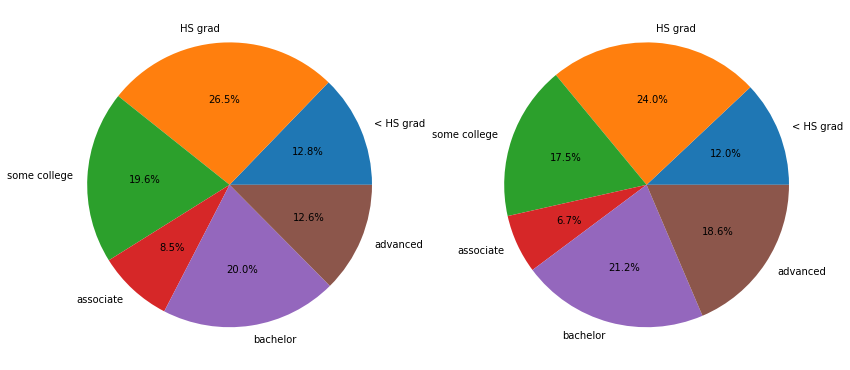

```python
mypiechart(ed)
```

**Figure 1.** Education level in the United States (left) and Maryland (right).

```python
y = census_data[ed[1:]].copy()
for col in ed[1:]:
    y[col] /= census_data['ed_total']
```

Now we have the data fields that are necessary to perform our analysis. However, a little housecleaning before we move on...

```python
# remove US aggregate from the states' data (it has served its purpose above)
census_data = census_data.loc[(census_data['state'] != 'United States')].reset_index(drop=True)
# sort by date
census_data.sort_values('state', inplace=True)
# re-index to sensible numbers
census_data.reset_index(inplace=True, drop=True)
census_data.head()
```

|  | state | total | male | female | race_total | White | Black | Am Indian & Al Native | Asian | Hispanic/Latin | median household earnings | poverty status | median age | ed_total | < HS grad | HS grad | some college | associate | bachelor | advanced |
| --- | --- | --- | --- | --- | --- | --- | --- | --- | --- | --- | --- | --- | --- | --- | --- | --- | --- | --- | --- | --- |
| 0 | Alabama | 4903185.0 | 2369611.0 | 2533574.0 | 4903185.0 | 3326375.0 | 1319551.0 | 23265.0 | 66129.0 | 219296.0 | 51734.0 | 739108.0 | 39.4 | 3360058.0 | 471504.0 | 1039241.0 | 700473.0 | 301914.0 | 547975.0 | 337382.0 |
| 1 | Alaska | 731545.0 | 380433.0 | 351112.0 | 731545.0 | 469771.0 | 22551.0 | 115544.0 | 43678.0 | NaN | 75463.0 | 71938.0 | 35.0 | 484058.0 | 37780.0 | 139156.0 | 124261.0 | 43394.0 | 89583.0 | 56574.0 |
| 2 | Arizona | 7278717.0 | 3620935.0 | 3657782.0 | 7278717.0 | 5701810.0 | 343729.0 | 332273.0 | 241721.0 | 2310592.0 | 62055.0 | 958442.0 | 38.3 | 4944540.0 | 680276.0 | 1170685.0 | 1236845.0 | 431854.0 | 931038.0 | 561120.0 |
| 3 | Arkansas | 3017804.0 | 1474705.0 | 1543099.0 | 3017804.0 | 2315020.0 | 467468.0 | 17216.0 | 46078.0 | 231951.0 | 48952.0 | 474739.0 | 38.8 | 2036456.0 | 273253.0 | 710306.0 | 444052.0 | 151738.0 | 307185.0 | 168182.0 |
| 4 | California | 39512223.0 | 19640794.0 | 19871429.0 | 39512223.0 | 23484958.0 | 2282144.0 | 321112.0 | 5865435.0 | 15574882.0 | 80440.0 | 4552837.0 | 37.0 | 26937872.0 | 4767048.0 | 5546711.0 | 5542372.0 | 2118792.0 | 5889724.0 | 3538760.0 |

## I. Data Collection, Curation, and Representation

### *Part B: CDC Data*

Compared to the Census download, only a small amount of data is required from the CDC. However, the CDC data presented processing challenges because of missing data. Drug overdose data were acquired from the CDC site https://data.cdc.gov/NCHS/VSRR-Provisional-Drug-Overdose-Death-Counts/xkb8-kh2a/

```python
cdc_data = pd.read_csv('VSRR_Provisional_Drug_Overdose_Death_Counts.csv')
cdc_data.head()
```

|  | State | Year | Month | Period | Indicator | Data Value | Percent Complete | Percent Pending Investigation | State Name | Footnote | Footnote Symbol | Predicted Value |
| --- | --- | --- | --- | --- | --- | --- | --- | --- | --- | --- | --- | --- |
| 0 | AK | 2015 | April | 12 month-ending | Number of Drug Overdose Deaths | 126.000000 | 100 | 0.0 | Alaska | Numbers may differ from published reports usin... | ** | 127.0 |
| 1 | AK | 2015 | April | 12 month-ending | Heroin (T40.1) | NaN | 100 | 0.0 | Alaska | Numbers may differ from published reports usin... | ** | NaN |
| 2 | AK | 2015 | April | 12 month-ending | Natural & semi-synthetic opioids (T40.2) | NaN | 100 | 0.0 | Alaska | Numbers may differ from published reports usin... | ** | NaN |
| 3 | AK | 2015 | April | 12 month-ending | Methadone (T40.3) | NaN | 100 | 0.0 | Alaska | Numbers may differ from published reports usin... | ** | NaN |
| 4 | AK | 2015 | April | 12 month-ending | Percent with drugs specified | 88.095238 | 100 | 0.0 | Alaska | Numbers may differ from published reports usin... | ** | NaN |

The CDC provides yearly numbers, however, we need only 2019 data for this study.

```python
# CDC data are presented as rolling 12-month totals (so we need to specify December and 2019)
cdc_data = cdc_data.loc[(cdc_data['Year'] == 2019) & (cdc_data['Month'] == 'December')]
pd.set_option('display.max_columns', None)
pd.set_option('display.max_rows', None)
cdc_data.head()
```

|  | State | Year | Month | Period | Indicator | Data Value | Percent Complete | Percent Pending Investigation | State Name | Footnote | Footnote Symbol | Predicted Value |
| --- | --- | --- | --- | --- | --- | --- | --- | --- | --- | --- | --- | --- |
| 600 | AK | 2019 | December | 12 month-ending | Number of Drug Overdose Deaths | 133.000000 | 100 | 0.0 | Alaska | Numbers may differ from published reports usin... | ** | 134.0 |
| 601 | AK | 2019 | December | 12 month-ending | Percent with drugs specified | 96.240602 | 100 | 0.0 | Alaska | Numbers may differ from published reports usin... | ** | NaN |
| 602 | AK | 2019 | December | 12 month-ending | Synthetic opioids, excl. methadone (T40.4) | 23.000000 | 100 | 0.0 | Alaska | Numbers may differ from published reports usin... | ** | 24.0 |
| 603 | AK | 2019 | December | 12 month-ending | Natural & semi-synthetic opioids (T40.2) | 41.000000 | 100 | 0.0 | Alaska | Numbers may differ from published reports usin... | ** | 42.0 |
| 604 | AK | 2019 | December | 12 month-ending | Methadone (T40.3) | NaN | 100 | 0.0 | Alaska | Numbers may differ from published reports usin... | ** | 10.0 |

The CDC database contains information about all drugs. So the next task is to isolate the opioid data.

```python
cdc_data.Indicator.unique()
```

```
array(['Number of Drug Overdose Deaths', 'Percent with drugs specified',
       'Synthetic opioids, excl. methadone (T40.4)',
       'Natural & semi-synthetic opioids (T40.2)', 'Methadone (T40.3)',
       'Heroin (T40.1)', 'Psychostimulants with abuse potential (T43.6)',
       'Opioids (T40.0-T40.4,T40.6)', 'Number of Deaths',
       'Cocaine (T40.5)',
       'Natural & semi-synthetic opioids, incl. methadone (T40.2, T40.3)',
       'Natural, semi-synthetic, & synthetic opioids, incl. methadone (T40.2-T40.4)'],
      dtype=object)
```

```python
cdc_data = cdc_data.loc[(cdc_data['Indicator'] == 'Number of Drug Overdose Deaths') |
                        (cdc_data['Indicator'] == 'Opioids (T40.0-T40.4,T40.6)')]
cdc_data.head()
```

|  | State | Year | Month | Period | Indicator | Data Value | Percent Complete | Percent Pending Investigation | State Name | Footnote | Footnote Symbol | Predicted Value |
| --- | --- | --- | --- | --- | --- | --- | --- | --- | --- | --- | --- | --- |
| 600 | AK | 2019 | December | 12 month-ending | Number of Drug Overdose Deaths | 133.0 | 100 | 0.000000 | Alaska | Numbers may differ from published reports usin... | ** | 134.0 |
| 607 | AK | 2019 | December | 12 month-ending | Opioids (T40.0-T40.4,T40.6) | 83.0 | 100 | 0.000000 | Alaska | Numbers may differ from published reports usin... | ** | 84.0 |
| 990 | AL | 2019 | December | 12 month-ending | Number of Drug Overdose Deaths | 739.0 | 100 | 0.219883 | Alabama | Numbers may differ from published reports usin... | ** | 759.0 |
| 1200 | AR | 2019 | December | 12 month-ending | Number of Drug Overdose Deaths | 362.0 | 100 | 0.043318 | Arkansas | Numbers may differ from published reports usin... | ** | 364.0 |
| 1860 | AZ | 2019 | December | 12 month-ending | Number of Drug Overdose Deaths | 1981.0 | 100 | 0.072028 | Arizona | Numbers may differ from published reports usin... | ** | 1999.0 |

```python
# isolate the important columns
cdc_data = cdc_data[['State Name', 'Indicator', 'Data Value']]
cdc_data.head()
```

|  | State Name | Indicator | Data Value |
| --- | --- | --- | --- |
| 600 | Alaska | Number of Drug Overdose Deaths | 133.0 |
| 607 | Alaska | Opioids (T40.0-T40.4,T40.6) | 83.0 |
| 990 | Alabama | Number of Drug Overdose Deaths | 739.0 |
| 1200 | Arkansas | Number of Drug Overdose Deaths | 362.0 |
| 1860 | Arizona | Number of Drug Overdose Deaths | 1981.0 |

```python
# pivot on Indicator column
cdc_data = cdc_data.pivot(index='State Name', columns='Indicator', values='Data Value').reset_index()
cdc_data.columns = ['state', 'all drugs', 'opioids']
cdc_data.head()
```

|  | state | all drugs | opioids |
| --- | --- | --- | --- |
| 0 | Alabama | 739.0 | NaN |
| 1 | Alaska | 133.0 | 83.0 |
| 2 | Arizona | 1981.0 | 1326.0 |
| 3 | Arkansas | 362.0 | NaN |
| 4 | California | 6363.0 | 3324.0 |

```python
# a national problem
national = cdc_data[cdc_data['state'] == 'United States']
print(national)
```

```
            state  all drugs  opioids
45  United States    71130.0  50178.0
```

Please pause for a moment to reflect on the magnitude of this ongoing crisis. *There were about 50,000 deaths from opioid overdoses in 2019.* In any year, other than a year of worldwide pandemic, this number would be shocking.

### Too Much Data

Before addressing the significant problem of missing data, we need to prune the dataset a bit. New York City is not a state, so it should be removed from the state-level list. Also, I will remove the US aggregate from the state-level data because, otherwise, it would interfere with the analytics (later in the report).

```python
cdc_data = cdc_data.loc[(cdc_data['state'] != 'New York City') &
        (cdc_data['state'] != 'United States')].reset_index(drop=True)
cdc_data.head()
```

|  | state | all drugs | opioids |
| --- | --- | --- | --- |
| 0 | Alabama | 739.0 | NaN |
| 1 | Alaska | 133.0 | 83.0 |
| 2 | Arizona | 1981.0 | 1326.0 |
| 3 | Arkansas | 362.0 | NaN |
| 4 | California | 6363.0 | 3324.0 |

### Missing Data

Fortunately, all states do report total drug overdoses ('all drugs' column in the above table). I propose that we use the complete set of total overdoses to fill-in the missing opioid data. To do this, we need to find a relationship between opioid overdoses and all-drug overdoses. The following analysis makes use of plotting routines from the matplotlib library and a polynomial fitting routine from the NumPy library.

```
linear regression (red):	m = 0.6568 	b =  78.7

linear regression (green):	m = 0.8404 	b = -91.2

linear regression (blue):	m = 0.7930 	b =   0.0
```

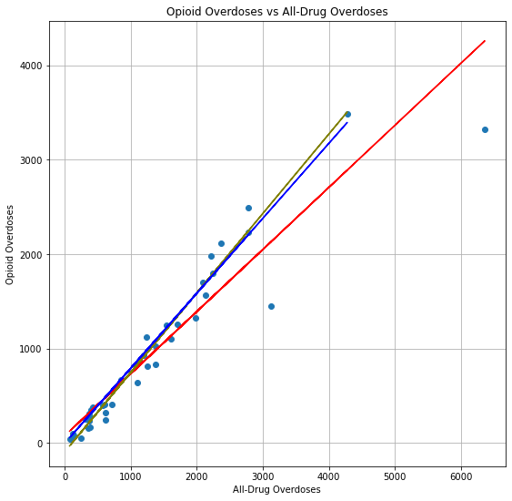

```python
# plot the data with three different least squares lines
fig, ax = plt.subplots(figsize=(9, 9))
ax.grid(True)
ax.plot(cdc_data['all drugs'], cdc_data['opioids'], 'o')
ax.set_xlabel('All-Drug Overdoses')
ax.set_ylabel('Opioid Overdoses')
ax.set_title('Opioid Overdoses vs All-Drug Overdoses')

# linear regression
clean_data = cdc_data.dropna()    # this should be done here!!!!
x = clean_data['all drugs'].values
y = clean_data['opioids'].values
m, b = np.polyfit(x, y, 1)
print('\nlinear regression (red):\tm = %6.4f' % m, '\tb = %5.1f' % b)
ax.plot(x, m*x + b, '-', color='red')

# Linear regression without outliers (California and Texas)
clean_data = clean_data[(clean_data['state'] != 'California') & (clean_data['state'] != 'Texas')]
x = clean_data['all drugs'].values
y = clean_data['opioids'].values
m, b = np.polyfit(x, y, 1)
print('\nlinear regression (green):\tm = %6.4f' % m, '\tb = %5.1f' % b)
ax.plot(x, m*x + b, '-', color='olive')

# compute LS line through the origin
m = np.linalg.lstsq(x.reshape(-1,1), y, rcond=-1)[0][0]
b = 0
print('\nlinear regression (blue):\tm = %6.4f' % m, '\tb = %5.1f' % b)
ax.plot(x, m*x + b, '-', color='blue')
```

**Figure 2.** This plot shows a linear relationship between opioid overdoses and all-drug overdoses. Three least squares lines are computed with all data (red), data without outliers (green), and data without outliers and constrained to have zero intercept (blue). See discussion for why there are so many least squares lines.

```python
# R-squared
y_pred = m*clean_data['all drugs'] + b
print('r-squared: %.3f' % r2_score(y, y_pred))
```

```
r-squared: 0.973
```

```python
# use m, b from least squares line to interpolate values for missing opioid data
cdc_data['opioids'] = np.where(cdc_data['opioids'].isna(), m*cdc_data['all drugs']+b, cdc_data['opioids'])
cdc_data.head()
```

|  | state | all drugs | opioids |
| --- | --- | --- | --- |
| 0 | Alabama | 739.0 | 586.051676 |
| 1 | Alaska | 133.0 | 83.000000 |
| 2 | Arizona | 1981.0 | 1326.000000 |
| 3 | Arkansas | 362.0 | 287.078088 |
| 4 | California | 6363.0 | 3324.000000 |

```python
# remove the all-drugs of the cdc data
cdc_data.drop('all drugs', inplace=True, axis=1)
cdc_data.head()
```

|  | state | opioids |
| --- | --- | --- |
| 0 | Alabama | 586.051676 |
| 1 | Alaska | 83.000000 |
| 2 | Arizona | 1326.000000 |
| 3 | Arkansas | 287.078088 |
| 4 | California | 3324.000000 |

### Merge the Census and the CDC datasets

```python
data_orig = pd.merge(left=census_data, right=cdc_data, left_on='state', right_on='state')
data_orig
```

|  | state | total | male | female | race_total | White | Black | Am Indian & Al Native | Asian | Hispanic/Latin | median household earnings | poverty status | median age | ed_total | < HS grad | HS grad | some college | associate | bachelor | advanced | opioids |
| --- | --- | --- | --- | --- | --- | --- | --- | --- | --- | --- | --- | --- | --- | --- | --- | --- | --- | --- | --- | --- | --- |
| 0 | Alabama | 4903185.0 | 2369611.0 | 2533574.0 | 4903185.0 | 3326375.0 | 1319551.0 | 23265.0 | 66129.0 | 219296.0 | 51734.0 | 739108.0 | 39.4 | 3360058.0 | 471504.0 | 1039241.0 | 700473.0 | 301914.0 | 547975.0 | 337382.0 | 586.051676 |
| 1 | Alaska | 731545.0 | 380433.0 | 351112.0 | 731545.0 | 469771.0 | 22551.0 | 115544.0 | 43678.0 | NaN | 75463.0 | 71938.0 | 35.0 | 484058.0 | 37780.0 | 139156.0 | 124261.0 | 43394.0 | 89583.0 | 56574.0 | 83.000000 |
| 2 | Arizona | 7278717.0 | 3620935.0 | 3657782.0 | 7278717.0 | 5701810.0 | 343729.0 | 332273.0 | 241721.0 | 2310592.0 | 62055.0 | 958442.0 | 38.3 | 4944540.0 | 680276.0 | 1170685.0 | 1236845.0 | 431854.0 | 931038.0 | 561120.0 | 1326.000000 |
| 3 | Arkansas | 3017804.0 | 1474705.0 | 1543099.0 | 3017804.0 | 2315020.0 | 467468.0 | 17216.0 | 46078.0 | 231951.0 | 48952.0 | 474739.0 | 38.8 | 2036456.0 | 273253.0 | 710306.0 | 444052.0 | 151738.0 | 307185.0 | 168182.0 | 287.078088 |
| 4 | California | 39512223.0 | 19640794.0 | 19871429.0 | 39512223.0 | 23484958.0 | 2282144.0 | 321112.0 | 5865435.0 | 15574882.0 | 80440.0 | 4552837.0 | 37.0 | 26937872.0 | 4767048.0 | 5546711.0 | 5542372.0 | 2118792.0 | 5889724.0 | 3538760.0 | 3324.000000 |
| 5 | Colorado | 5758736.0 | 2904955.0 | 2853781.0 | 5758736.0 | 4822379.0 | 240538.0 | 57578.0 | 188461.0 | 1256903.0 | 77127.0 | 526979.0 | 37.1 | 3974943.0 | 375802.0 | 836590.0 | 805570.0 | 334961.0 | 1057825.0 | 637777.0 | 644.000000 |
| 6 | Connecticut | 3565287.0 | 1743777.0 | 1821510.0 | 3565287.0 | 2660228.0 | 396745.0 | 9052.0 | 166393.0 | 600954.0 | 78833.0 | 347149.0 | 41.2 | 2496420.0 | 274394.0 | 668361.0 | 410972.0 | 190700.0 | 549166.0 | 445382.0 | 1119.000000 |
| 7 | Delaware | 973764.0 | 470288.0 | 503476.0 | 973764.0 | 659719.0 | 219418.0 | 4353.0 | 36592.0 | 93390.0 | 70176.0 | 106383.0 | 41.4 | 687311.0 | 78142.0 | 207642.0 | 128063.0 | 56885.0 | 134287.0 | 93912.0 | 382.000000 |
| 8 | District of Columbia | 705749.0 | 334355.0 | 371394.0 | 705749.0 | 300058.0 | 320704.0 | 1886.0 | 28722.0 | 79477.0 | 92266.0 | 90534.0 | 34.3 | 505145.0 | 60920.0 | 79881.0 | 65745.0 | 16922.0 | 129825.0 | 171604.0 | 281.000000 |
| 9 | Florida | 21477737.0 | 10498005.0 | 10979732.0 | 21477737.0 | 16010079.0 | 3441062.0 | 59558.0 | 599799.0 | 5663629.0 | 59227.0 | 2664772.0 | 42.4 | 15484502.0 | 1976753.0 | 4396122.0 | 3001381.0 | 1538727.0 | 2982643.0 | 1770994.0 | 4380.716453 |
| 10 | Georgia | 10617423.0 | 5170126.0 | 5447297.0 | 10617423.0 | 6131699.0 | 3390968.0 | 42316.0 | 439416.0 | 1042642.0 | 61980.0 | 1373909.0 | 37.2 | 7080222.0 | 953847.0 | 1939945.0 | 1414554.0 | 568130.0 | 1410395.0 | 891173.0 | 837.000000 |
| 11 | Hawaii | 1415872.0 | 707855.0 | 708017.0 | 1415872.0 | 341211.0 | 26923.0 | 6129.0 | 547843.0 | 150864.0 | 83102.0 | 128722.0 | 39.6 | 996668.0 | 91028.0 | 273421.0 | 205964.0 | 106096.0 | 219979.0 | 115230.0 | 56.000000 |
| 12 | Idaho | 1787065.0 | 898044.0 | 889021.0 | 1787065.0 | 1596918.0 | 12708.0 | 22867.0 | 25969.0 | 229494.0 | 60999.0 | 195984.0 | 36.9 | 1170997.0 | 115006.0 | 305274.0 | 304578.0 | 124584.0 | 220189.0 | 116466.0 | 209.360815 |
| 13 | Illinois | 12671821.0 | 6217305.0 | 6454516.0 | 12671821.0 | 9044059.0 | 1790212.0 | 32600.0 | 717992.0 | 2216300.0 | 69187.0 | 1420542.0 | 38.6 | 8694694.0 | 1006355.0 | 2255611.0 | 1737416.0 | 710058.0 | 1886240.0 | 1222732.0 | 2232.000000 |
| 14 | Indiana | 6732219.0 | 3319907.0 | 3412312.0 | 6732219.0 | 5571899.0 | 643105.0 | 18416.0 | 170566.0 | 485554.0 | 57603.0 | 775823.0 | 38.0 | 4502015.0 | 518895.0 | 1526825.0 | 896654.0 | 397627.0 | 777771.0 | 435055.0 | 1256.000000 |
| 15 | Iowa | 3155070.0 | 1570384.0 | 1584686.0 | 3155070.0 | 2835536.0 | 129335.0 | 11837.0 | 76134.0 | 197482.0 | 61691.0 | 341613.0 | 38.5 | 2123004.0 | 184048.0 | 658822.0 | 433870.0 | 251578.0 | 420199.0 | 202054.0 | 157.000000 |
| 16 | Kansas | 2913314.0 | 1446287.0 | 1467027.0 | 2913314.0 | 2436902.0 | 167237.0 | 23860.0 | 87018.0 | 354804.0 | 62087.0 | 323189.0 | 37.2 | 1918081.0 | 181165.0 | 504035.0 | 430549.0 | 173251.0 | 414851.0 | 237638.0 | 171.000000 |
| 17 | Kentucky | 4467673.0 | 2198205.0 | 2269468.0 | 4467673.0 | 3873691.0 | 363167.0 | 8326.0 | 73087.0 | 168017.0 | 52295.0 | 703627.0 | 39.2 | 3048442.0 | 423995.0 | 1012643.0 | 619035.0 | 260188.0 | 453040.0 | 312883.0 | 1024.000000 |
| 18 | Louisiana | 4648794.0 | 2268202.0 | 2380592.0 | 4648794.0 | 2874784.0 | 1504017.0 | 28561.0 | 81506.0 | 250203.0 | 51073.0 | 857894.0 | 37.7 | 3140201.0 | 471360.0 | 1066026.0 | 646746.0 | 202310.0 | 503947.0 | 280328.0 | 1034.115542 |
| 19 | Maine | 1344212.0 | 656330.0 | 687882.0 | 1344212.0 | 1263287.0 | 21983.0 | 9419.0 | 15323.0 | 23067.0 | 58924.0 | 141803.0 | 45.1 | 991152.0 | 82209.0 | 311108.0 | 184723.0 | 99008.0 | 205722.0 | 123277.0 | 317.000000 |
| 20 | Maryland | 6045680.0 | 2928013.0 | 3117667.0 | 6045680.0 | 3296909.0 | 1830059.0 | 19164.0 | 386194.0 | 643171.0 | 86738.0 | 532241.0 | 39.0 | 4183858.0 | 516378.0 | 1030636.0 | 753547.0 | 287293.0 | 911781.0 | 798449.0 | 2117.000000 |
| 21 | Massachusetts | 6892503.0 | 3345556.0 | 3546947.0 | 6892503.0 | 5305385.0 | 543629.0 | 17875.0 | 472895.0 | 853735.0 | 85843.0 | 625763.0 | 39.7 | 4850576.0 | 563105.0 | 1158066.0 | 729016.0 | 360810.0 | 1197208.0 | 984535.0 | 1977.000000 |
| 22 | Michigan | 9986857.0 | 4915905.0 | 5070952.0 | 9986857.0 | 7812165.0 | 1371069.0 | 57785.0 | 327230.0 | 525973.0 | 59584.0 | 1269062.0 | 39.8 | 6894627.0 | 681730.0 | 2005981.0 | 1572770.0 | 648794.0 | 1252685.0 | 818110.0 | 1869.972737 |
| 23 | Minnesota | 5639632.0 | 2804216.0 | 2835416.0 | 5639632.0 | 4627588.0 | 370291.0 | 57414.0 | 285630.0 | 314217.0 | 74593.0 | 494683.0 | 38.4 | 3847212.0 | 300528.0 | 939997.0 | 785721.0 | 442578.0 | 942830.0 | 490396.0 | 624.910312 |
| 24 | Mississippi | 2976149.0 | 1434957.0 | 1541192.0 | 2976149.0 | 1726970.0 | 1130608.0 | 14634.0 | 31154.0 | 90143.0 | 45792.0 | 564192.0 | 38.3 | 1979664.0 | 310761.0 | 598609.0 | 440939.0 | 207448.0 | 270712.0 | 171039.0 | 231.000000 |
| 25 | Missouri | 6137428.0 | 3008169.0 | 3129259.0 | 6137428.0 | 5022939.0 | 703058.0 | 25516.0 | 127154.0 | 264334.0 | 57409.0 | 770175.0 | 38.9 | 4206162.0 | 447755.0 | 1308859.0 | 900486.0 | 333721.0 | 775808.0 | 495473.0 | 1105.000000 |
| 26 | Montana | 1068778.0 | 537170.0 | 531608.0 | 1068778.0 | 940423.0 | 7787.0 | 67603.0 | 8927.0 | NaN | 57153.0 | 131882.0 | 40.5 | 741950.0 | 53249.0 | 211079.0 | 169641.0 | 69400.0 | 171309.0 | 77839.0 | 110.231641 |
| 27 | Nebraska | 1934408.0 | 966650.0 | 967758.0 | 1934408.0 | 1666763.0 | 94659.0 | 18964.0 | 47740.0 | 219472.0 | 63229.0 | 185761.0 | 36.8 | 1271770.0 | 118231.0 | 326389.0 | 280333.0 | 141189.0 | 277159.0 | 145428.0 | 115.782875 |
| 28 | Nevada | 3080156.0 | 1544779.0 | 1535377.0 | 3080156.0 | 1989116.0 | 296184.0 | 42426.0 | 261159.0 | 900599.0 | 63276.0 | 379564.0 | 38.4 | 2136466.0 | 305148.0 | 593417.0 | 525746.0 | 187469.0 | 355837.0 | 193082.0 | 411.000000 |
| 29 | New Hampshire | 1359711.0 | 672960.0 | 686751.0 | 1359711.0 | 1258576.0 | 22000.0 | 1727.0 | 35807.0 | 54182.0 | 77933.0 | 95711.0 | 43.0 | 979750.0 | 79063.0 | 275105.0 | 174078.0 | 96658.0 | 224636.0 | 143601.0 | 354.000000 |
| 30 | New Jersey | 8882190.0 | 4342591.0 | 4539599.0 | 8882190.0 | 5964295.0 | 1203843.0 | 18440.0 | 856561.0 | 1856845.0 | 85751.0 | 798262.0 | 40.2 | 6191229.0 | 707694.0 | 1666321.0 | 974540.0 | 398984.0 | 1555781.0 | 995984.0 | 2487.000000 |
| 31 | New Mexico | 2096829.0 | 1036708.0 | 1060121.0 | 2096829.0 | 1549953.0 | 48337.0 | 199341.0 | 36549.0 | 1032950.0 | 51945.0 | 373230.0 | 38.6 | 1425988.0 | 229112.0 | 376390.0 | 324141.0 | 129531.0 | 221281.0 | 173317.0 | 405.000000 |
| 32 | New York | 19453561.0 | 9450810.0 | 10002751.0 | 19453561.0 | 12293680.0 | 3084304.0 | 73560.0 | 1680219.0 | 3749257.0 | 72108.0 | 2467006.0 | 39.2 | 13664734.0 | 1906861.0 | 3524192.0 | 2075506.0 | 1204588.0 | 2898440.0 | 2267778.0 | 1700.000000 |
| 33 | North Carolina | 10488084.0 | 5094327.0 | 5393757.0 | 10488084.0 | 7144510.0 | 2253481.0 | 126708.0 | 309905.0 | 1022995.0 | 57341.0 | 1386122.0 | 39.1 | 7187077.0 | 921482.0 | 1839042.0 | 1480044.0 | 727882.0 | 1471420.0 | 849765.0 | 1793.000000 |
| 34 | North Dakota | 762062.0 | 388339.0 | 373723.0 | 762062.0 | 653910.0 | 22256.0 | 40970.0 | 10669.0 | NaN | 64577.0 | 78112.0 | 35.5 | 504375.0 | 39403.0 | 134432.0 | 112811.0 | 70716.0 | 108527.0 | 44870.0 | 71.373005 |
| 35 | Ohio | 11689100.0 | 5732207.0 | 5956893.0 | 11689100.0 | 9452650.0 | 1467331.0 | 23544.0 | 274585.0 | 467589.0 | 58642.0 | 1484862.0 | 39.6 | 8049805.0 | 832215.0 | 2627758.0 | 1622014.0 | 702601.0 | 1464945.0 | 891640.0 | 3484.000000 |
| 36 | Oklahoma | 3956971.0 | 1962477.0 | 1994494.0 | 3956971.0 | 2865785.0 | 287414.0 | 316929.0 | 89950.0 | 438106.0 | 54449.0 | 583029.0 | 37.0 | 2619244.0 | 331949.0 | 825284.0 | 596289.0 | 207896.0 | 447888.0 | 238621.0 | 249.000000 |
| 37 | Oregon | 4217737.0 | 2089676.0 | 2128061.0 | 4217737.0 | 3523853.0 | 77918.0 | 50417.0 | 194068.0 | 566839.0 | 67058.0 | 470643.0 | 39.7 | 2988118.0 | 316181.0 | 687243.0 | 741058.0 | 269102.0 | 627911.0 | 404405.0 | 326.000000 |
| 38 | Pennsylvania | 12801989.0 | 6272527.0 | 6529462.0 | 12801989.0 | 10193792.0 | 1454753.0 | 27088.0 | 453662.0 | 997830.0 | 63463.0 | 1489333.0 | 40.8 | 9028036.0 | 950118.0 | 3103046.0 | 1420062.0 | 775694.0 | 1761627.0 | 1155775.0 | 3524.240391 |
| 39 | Rhode Island | 1059361.0 | 517221.0 | 542140.0 | 1059361.0 | 833690.0 | 78143.0 | 3341.0 | 37101.0 | 172643.0 | 71169.0 | 110244.0 | 40.1 | 746952.0 | 92933.0 | 212282.0 | 129984.0 | 64204.0 | 156087.0 | 104188.0 | 252.000000 |
| 40 | South Carolina | 5148714.0 | 2485001.0 | 2663713.0 | 5148714.0 | 3434467.0 | 1362917.0 | 18971.0 | 86571.0 | 298478.0 | 56227.0 | 692744.0 | 39.9 | 3563204.0 | 454617.0 | 1015260.0 | 725158.0 | 352549.0 | 656496.0 | 398063.0 | 876.000000 |
| 41 | South Dakota | 884659.0 | 449458.0 | 435201.0 | 884659.0 | 743764.0 | 20866.0 | 75809.0 | 11530.0 | NaN | 59533.0 | 101946.0 | 37.7 | 588029.0 | 52888.0 | 176644.0 | 120476.0 | 69831.0 | 121231.0 | 53553.0 | 38.000000 |
| 42 | Tennessee | 6829174.0 | 3329115.0 | 3500059.0 | 6829174.0 | 5272910.0 | 1141304.0 | 20431.0 | 125742.0 | 389127.0 | 56071.0 | 922176.0 | 39.0 | 4693962.0 | 631227.0 | 1480753.0 | 953282.0 | 348886.0 | 845100.0 | 503124.0 | 1566.000000 |
| 43 | Texas | 28995881.0 | 14385762.0 | 14610119.0 | 28995881.0 | 21273326.0 | 3553922.0 | 144993.0 | 1446073.0 | 11524842.0 | 64034.0 | 3865010.0 | 35.1 | 18772550.0 | 3104575.0 | 4734422.0 | 3976607.0 | 1402600.0 | 3750797.0 | 2025736.0 | 1452.000000 |
| 44 | Utah | 3205958.0 | 1610671.0 | 1595287.0 | 3205958.0 | 2799527.0 | 36918.0 | 35368.0 | 76470.0 | 462054.0 | 75780.0 | 281279.0 | 31.2 | 1911592.0 | 160462.0 | 442206.0 | 486888.0 | 184777.0 | 448109.0 | 216552.0 | 399.000000 |
| 45 | Vermont | 623989.0 | 309164.0 | 314825.0 | 623989.0 | 585117.0 | 9435.0 | 2928.0 | 8603.0 | NaN | 63001.0 | 60897.0 | 42.8 | 445558.0 | 38180.0 | 129254.0 | 74468.0 | 38706.0 | 101015.0 | 71257.0 | 102.000000 |
| 46 | Virginia | 8535519.0 | 4201799.0 | 4333720.0 | 8535519.0 | 5714646.0 | 1659908.0 | 23388.0 | 565643.0 | 828154.0 | 76456.0 | 822775.0 | 38.5 | 5872757.0 | 700082.0 | 1387610.0 | 1107258.0 | 468107.0 | 1312800.0 | 1012270.0 | 1252.000000 |
| 47 | Washington | 7614893.0 | 3807572.0 | 3807321.0 | 7614893.0 | 5651091.0 | 305924.0 | 103882.0 | 684967.0 | 991723.0 | 78687.0 | 730240.0 | 37.9 | 5290324.0 | 529786.0 | 1167347.0 | 1199747.0 | 527524.0 | 1204728.0 | 750904.0 | 815.000000 |
| 48 | West Virginia | 1792147.0 | 885861.0 | 906286.0 | 1792147.0 | 1668004.0 | 65925.0 | 3601.0 | 14311.0 | NaN | 48850.0 | 278734.0 | 42.9 | 1281086.0 | 176614.0 | 515431.0 | 229877.0 | 101267.0 | 161686.0 | 108020.0 | 665.000000 |
| 49 | Wisconsin | 5822434.0 | 2892804.0 | 2929630.0 | 5822434.0 | 4963354.0 | 374747.0 | 54577.0 | 167420.0 | 412769.0 | 64168.0 | 591486.0 | 39.9 | 4015285.0 | 340149.0 | 1223392.0 | 804271.0 | 438381.0 | 829878.0 | 428501.0 | 929.000000 |
| 50 | Wyoming | 578759.0 | 296005.0 | 282754.0 | 578759.0 | 525860.0 | 7116.0 | 13774.0 | 4633.0 | NaN | 65003.0 | 56945.0 | 38.1 | 389847.0 | 26135.0 | 117501.0 | 93505.0 | 44034.0 | 73183.0 | 40374.0 | 43.000000 |

### Normalize the data before analysis

Most of the Census data represent numbers of people (except state, median household earnings, and median age). Before proceeding, we will normalize each group of data by its respective total.

```python
data = data_orig   # the working dataset (data), will contain the normalized data
```

```python
for col in gender[1:]:
    data[col] /= data['total']
for col in race[1:]:
    data[col] /= data['race_total']
for col in ed[1:]:
    data[col] /= data['ed_total']
data['poverty status'] /= census_data['total']
data.head()
```

|  | state | total | male | female | race_total | White | Black | Am Indian & Al Native | Asian | Hispanic/Latin | median household earnings | poverty status | median age | ed_total | < HS grad | HS grad | some college | associate | bachelor | advanced | opioids |
| --- | --- | --- | --- | --- | --- | --- | --- | --- | --- | --- | --- | --- | --- | --- | --- | --- | --- | --- | --- | --- | --- |
| 0 | Alabama | 4903185.0 | 0.483280 | 0.516720 | 4903185.0 | 0.678411 | 0.269121 | 0.004745 | 0.013487 | 219296.0 | 51734.0 | 0.150740 | 39.4 | 3360058.0 | 0.140326 | 0.309293 | 0.208471 | 0.089854 | 0.163085 | 0.100410 | 586.051676 |
| 1 | Alaska | 731545.0 | 0.520040 | 0.479960 | 731545.0 | 0.642163 | 0.030827 | 0.157945 | 0.059707 | NaN | 75463.0 | 0.098337 | 35.0 | 484058.0 | 0.078048 | 0.287478 | 0.256707 | 0.089646 | 0.185067 | 0.116874 | 83.000000 |
| 2 | Arizona | 7278717.0 | 0.497469 | 0.502531 | 7278717.0 | 0.783354 | 0.047224 | 0.045650 | 0.033209 | 2310592.0 | 62055.0 | 0.131677 | 38.3 | 4944540.0 | 0.137581 | 0.236763 | 0.250144 | 0.087340 | 0.188296 | 0.113483 | 1326.000000 |
| 3 | Arkansas | 3017804.0 | 0.488668 | 0.511332 | 3017804.0 | 0.767121 | 0.154903 | 0.005705 | 0.015269 | 231951.0 | 48952.0 | 0.157313 | 38.8 | 2036456.0 | 0.134181 | 0.348795 | 0.218051 | 0.074511 | 0.150843 | 0.082586 | 287.078088 |
| 4 | California | 39512223.0 | 0.497081 | 0.502919 | 39512223.0 | 0.594372 | 0.057758 | 0.008127 | 0.148446 | 15574882.0 | 80440.0 | 0.115226 | 37.0 | 26937872.0 | 0.176965 | 0.205908 | 0.205746 | 0.078655 | 0.218641 | 0.131367 | 3324.000000 |

Normalize opioid numbers to deaths per 100,000 people. Note this occurs after the merger to allow access to population numbers.

```python
# normalize opioid numbers to deaths per 100,000 people
data['opioids'] *= 100000 / data['total']
data.head()
```

|  | state | total | male | female | race_total | White | Black | Am Indian & Al Native | Asian | Hispanic/Latin | median household earnings | poverty status | median age | ed_total | < HS grad | HS grad | some college | associate | bachelor | advanced | opioids |
| --- | --- | --- | --- | --- | --- | --- | --- | --- | --- | --- | --- | --- | --- | --- | --- | --- | --- | --- | --- | --- | --- |
| 0 | Alabama | 4903185.0 | 0.483280 | 0.516720 | 4903185.0 | 0.678411 | 0.269121 | 0.004745 | 0.013487 | 219296.0 | 51734.0 | 0.150740 | 39.4 | 3360058.0 | 0.140326 | 0.309293 | 0.208471 | 0.089854 | 0.163085 | 0.100410 | 11.952469 |
| 1 | Alaska | 731545.0 | 0.520040 | 0.479960 | 731545.0 | 0.642163 | 0.030827 | 0.157945 | 0.059707 | NaN | 75463.0 | 0.098337 | 35.0 | 484058.0 | 0.078048 | 0.287478 | 0.256707 | 0.089646 | 0.185067 | 0.116874 | 11.345850 |
| 2 | Arizona | 7278717.0 | 0.497469 | 0.502531 | 7278717.0 | 0.783354 | 0.047224 | 0.045650 | 0.033209 | 2310592.0 | 62055.0 | 0.131677 | 38.3 | 4944540.0 | 0.137581 | 0.236763 | 0.250144 | 0.087340 | 0.188296 | 0.113483 | 18.217496 |
| 3 | Arkansas | 3017804.0 | 0.488668 | 0.511332 | 3017804.0 | 0.767121 | 0.154903 | 0.005705 | 0.015269 | 231951.0 | 48952.0 | 0.157313 | 38.8 | 2036456.0 | 0.134181 | 0.348795 | 0.218051 | 0.074511 | 0.150843 | 0.082586 | 9.512814 |
| 4 | California | 39512223.0 | 0.497081 | 0.502919 | 39512223.0 | 0.594372 | 0.057758 | 0.008127 | 0.148446 | 15574882.0 | 80440.0 | 0.115226 | 37.0 | 26937872.0 | 0.176965 | 0.205908 | 0.205746 | 0.078655 | 0.218641 | 0.131367 | 8.412587 |

This concludes the data preparation section of the tutorial. The next section will use these data to perform exploratory data analysis.

## II. Exploratory Data Analysis

We are now ready to do some analysis on the combined Census and CDC dataset. The primary objective of exploratory data analysis is to discover relationships between (or among) the data. In this study, we are interested in relationships between the demographic attributes and opioid deaths.

```
0 < HS grad
1 HS grad
2 some college
3 associate
4 bachelor
5 advanced
```

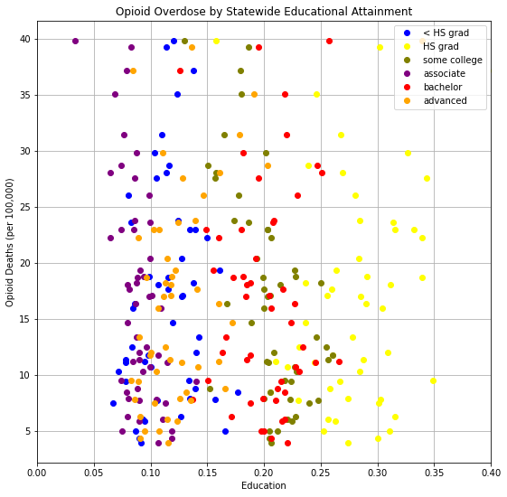

```python
fig, ax = plt.subplots(figsize=(9, 9))
ax.grid(True)
ax.set_xlim([0,0.4])
color = ['blue', 'yellow',  'olive', 'purple', 'red', 'orange', 'black']
for i,x in enumerate(ed[1:]):
    print(i, x)
    ax.plot(data[x], data['opioids'], 'o', color=color[i])
ax.set_xlabel('Education')
ax.set_ylabel('Opioid Deaths (per 100,000)')
ax.set_title('Opioid Overdose by Statewide Educational Attainment')
ax.legend(ed[1:])
```

**Figure 3.** Relationships between opioid deaths and education.

The above plot is a bit "noisy", so let's look at some individual education levels.

```python
def plot_one_ed(level, color):
    fig, ax = plt.subplots(figsize=(9, 9))
    ax.grid(True)
    ax.plot(data[level], data['opioids'], 'o', color=color)

    x = data[level].values
    y = data['opioids'].values
    m1, b1 = np.polyfit(x, y, 1)
    print('\nlinear regression (red):\tm = %6.4f' % m1, '\tb = %5.1f' % b1)
    ax.plot(x, m1*x + b1, '-', color='blue')

    ax.set_xlabel('Population Proportion')
    ax.set_ylabel('Opioid Deaths (per 100,000)')
    ax.set_title('Opioid Overdose by Statewide Educational Attainment')
    ax.legend([level])
```

```python
for x in ed[1:]:
    m, b = np.polyfit(data[x], data['opioids'], 1)
    print(x, "\t", m, "\t", b)
```

```
< HS grad 	 45.10879784696718 	 11.68782590575606
HS grad 	 30.19788223441717 	 8.366007548494796
some college 	 -199.19940568482053 	 57.563696778726815
associate 	 -308.974455401968 	 44.6161459771991
bachelor 	 1.8269399153686792 	 16.44483713962572
advanced 	 112.4102005133211 	 2.598140061653616
```

```
0 White
1 Black
2 Am Indian & Al Native
3 Asian
```

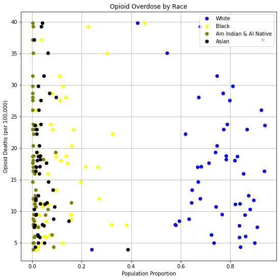

```python
fig, ax = plt.subplots(figsize=(9, 9))
ax.grid(True)
#ax.set_xlim([0,0.4])
color = ['blue', 'yellow',  'olive', 'black', 'red', 'orange','purple']
for i,x in enumerate(race[1:]):
    print(i, x)
    ax.plot(data[x], data['opioids'], 'o', color=color[i])
ax.set_xlabel('Population Proportion')
ax.set_ylabel('Opioid Deaths (per 100,000)')
ax.set_title('Opioid Overdose by Race')
ax.legend(race[1:])
```

**Figure 4.** Relationship between opioid deaths and race. There does not seem to be a discernable trend for White or Black people. The other two racial groups are difficult to read at this scale.

```python
def plot_one_gender(level):
    fig, ax = plt.subplots(figsize=(9, 9))
    ax.grid(True)
    ax.plot(data[level], data['opioids'], 'o', color='blue')

    x = data[level].values
    y = data['opioids'].values
    m1, b1 = np.polyfit(x, y, 1)
    print('\nlinear regression (red):\tm = %6.4f' % m1, '\tb = %5.1f' % b1)
    ax.plot(x, m1*x + b1, '-', color='red')

    ax.set_xlabel('Gender')
    ax.set_ylabel('Opioid Deaths (per 100,000)')
    ax.set_title('Opioid Overdose by Gender')
    ax.legend([level])
```

```
linear regression (red):	m = -624.8824 	b = 325.4
```

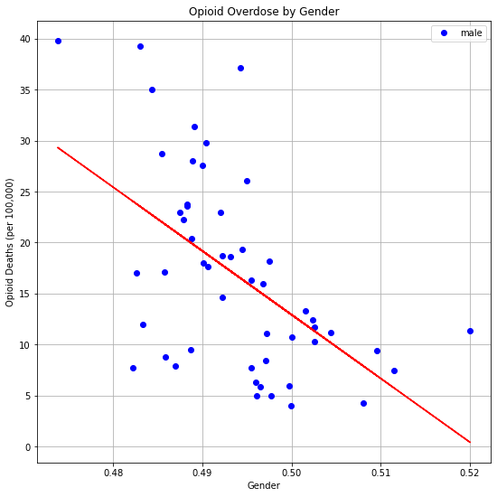

```python
plot_one_gender('male')
```

**Figure 5.** Relationship between opioid deaths and gender (males) with a LS line fitted to the data.

```python
#corrMatrix = data.corr(method ='pearson')
#fig, ax = plt.subplots(figsize=(11,9))
#sn.heatmap(corrMatrix, annot=True, cmap='coolwarm')
```

## III. Hypothesis Testing and Machine Learning

### Hypothesis: Demographic data can predict the opioid death rate by state.

I want to determine whether specific demographic characteristics of the general population can predict the prevalence of opioid overdoses. The go-to method for fitting polynomial functions is polyfit() from the NumPy library. But polyfit() can't be used on multivariate problems, as we have here. So, instead, I will implement linear regression with machine learning.

### Machine Learning

```python
lr = LinearRegression()
X = data[['male', 'median age', 'advanced']]
#X = data[['male', 'Black', 'median age', 'median household earnings', 'some college','advanced']]
y = data['opioids']
print(X.shape,y.shape)
lr.fit(X,y)
print(lr.intercept_)
print(lr.coef_)
y_pred = lr.predict(X)
```

```
(51, 3) (51,)
108.10328165903542
[-315.55853495    1.3721078    89.33497052]
```

```python
results = pd.DataFrame()
results['actual'] = y
results['predict'] = y_pred
results['diff'] = y_pred - y
results.head()
```

|  | actual | predict | diff |
| --- | --- | --- | --- |
| 0 | 11.952469 | 18.631303 | 6.678834 |
| 1 | 11.345850 | 2.464822 | -8.881029 |
| 2 | 18.217496 | 13.812446 | -4.405050 |
| 3 | 9.512814 | 14.515412 | 5.002598 |
| 4 | 8.412587 | 13.748678 | 5.336091 |

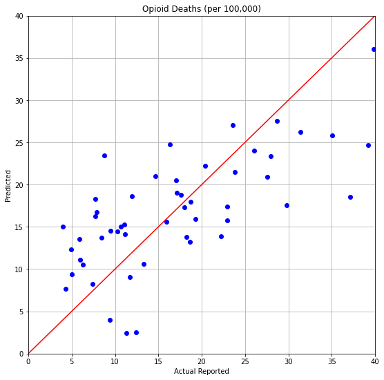

```python
fig, ax = plt.subplots(figsize=(9, 9))
ax.grid(True)
ax.set_xlim([0,40])
ax.set_ylim([0,40])
ax.plot(results['actual'], results['predict'], 'o', color='blue')
ax.plot([0,40], [0,40], '-', color='red')
ax.set_xlabel('Actual Reported')
ax.set_ylabel('Predicted')
ax.set_title('Opioid Deaths (per 100,000)')
#ax.legend(['orig', 'pred'])
```

### Test Hypothesis

The null hypothesis is that there is no relationship between the attributes (e.g., 'male', 'median age') and the actual number of opioid cases. A p-value close to 0 means the the null hypothesis is rejected. First, let's take a look at the p-values for the coefficients.

```python
import statsmodels.api as sm
from scipy import stats

#X = x
X2 = sm.add_constant(X)
ls_est = sm.OLS(y, X2)
est = ls_est.fit()
print(ls_est.fit().summary())
```

```
                            OLS Regression Results
==============================================================================
Dep. Variable:                opioids   R-squared:                       0.475
Model:                            OLS   Adj. R-squared:                  0.442
Method:                 Least Squares   F-statistic:                     14.18
Date:                Mon, 17 May 2021   Prob (F-statistic):           1.03e-06
Time:                        19:48:11   Log-Likelihood:                -170.94
No. Observations:                  51   AIC:                             349.9
Df Residuals:                      47   BIC:                             357.6
Df Model:                           3
Covariance Type:            nonrobust
==============================================================================
                 coef    std err          t      P>|t|      [0.025      0.975]
------------------------------------------------------------------------------
const        108.1033     81.417      1.328      0.191     -55.687     271.893
male        -315.5585    143.695     -2.196      0.033    -604.636     -26.481
median age     1.3721      0.468      2.929      0.005       0.430       2.315
advanced      89.3350     27.674      3.228      0.002      33.662     145.008
==============================================================================
Omnibus:                        1.304   Durbin-Watson:                   1.956
Prob(Omnibus):                  0.521   Jarque-Bera (JB):                1.155
Skew:                           0.358   Prob(JB):                        0.561
Kurtosis:                       2.822   Cond. No.                     6.37e+03
==============================================================================

Notes:
[1] Standard Errors assume that the covariance matrix of the errors is correctly specified.
[2] The condition number is large, 6.37e+03. This might indicate that there are
strong multicollinearity or other numerical problems.
```

## IV. Insights

This project has given me several insights into the opioid crisis and data science, in general. Opioid abuse is an ongoing, devastating crisis. This project looked at statewide demographic data. It showed that some attributes have a moderate correlation with the incidence of opioid deaths by state. For example, the median age and advanced degrees in a state has some predictive value. The ideal study would not look at statewide data but rather individual persons with full descriptions of their personal traits. Then, a full-scale machine learning algorithm could be applied.

I looked very hard for relationships in the data but the main result of the model is disappointing. However, at the end of the day, you can't let your preconceived notions dictate your investigation. Instead, you have to listen to the data and let it guide you. The relationship between population demographics and opioid overdoses warrants further investigation. The next steps, in perhaps another tutorial, would be to gather additional information from the Census Bureau and the CDC, and also investigate other data sources. Further investigation could also apply additional tools such as principal component analysis and various machine learning techniques.

For now, I say farewell. I hope you enjoyed the tutorial!